# Danielson Regression

```r
library(tidyverse)
library(arrow)
library(ResourceSelection)
library(ggpubr)
library(pander)

all <- read_parquet("../../Scripts/All_teacher_info.parquet") %>%
  filter(!is.na(WDanielson_highest_level))
```

## Danielson

This analysis builds off the aggregation of Danielson observations recorded in [this article](https://sites.google.com/view/benjamin-pacini/dissertation/data-overview/danielson-fft?authuser=0).  
In summary, we’ve condensed down the Danielson observations across dozens of classes and individual reports based on three criteria:

1. We’ve prioritized observations from the classes furthest along in the student’s career. For most students, we use their scores from ED 492, but for those missing observations, we use any other 400-level, then 300- and 200-level class.
2. If a student has more than one observation recorded for the class, we prioritize the summative evaluations over the formative ones.
3. To compensate for different grading standards across teachers, we’ve turned each raw final score (a 3-pt scale of 22 questions) into a z_score. Now each score reflects how the student did in this class compared to their peers.-

$$zscore = \frac{x_{StudentScore} - \mu_{TeacherAndSemester}}{\sigma_{TeacherAndSemester}}$$
After these steps, we go from 9854 individual observations to 1776 values tied to student records.

```r
all %>%
  select(WDanielson_highest_level,CurrentCumGPA,ACTSAT_Scores,isMale,
         ReceivedPell,Ethnicity, NumSem, YearStarted) %>%
  head(5) %>%
  pander()
```

Table continues below

| WDanielson_highest_level | CurrentCumGPA | ACTSAT_Scores | isMale |
| --- | --- | --- | --- |
| -0.607 | 4 | NA | 0 |
| 2.028 | NA | 27 | 0 |
| 0.211 | 3.3 | NA | 0 |
| 0.246 | 4 | 28 | 0 |
| 0.732 | 4 | 32 | 1 |

| ReceivedPell | Ethnicity | NumSem | YearStarted |
| --- | --- | --- | --- |
| 1 | White | 3 | 23 |
| 0 | White | 1 | 23 |
| 1 | White | 3 | 23 |
| 0 | Unknown | 3 | 23 |
| 1 | Hispanic, Latino | 4 | 22 |

It’s important to notice that because we made all these adjustments from the raw observations, this analysis won’t be useful for predicting individual scores. This can only tell which other metrics are most likely to help students succeed.

### Danielson against GPA

```r
lm_dan_gpa <- lm(WDanielson_highest_level ~ CurrentCumGPA, data = all)
summary(lm_dan_gpa) %>% pander::pander()
```

|  | Estimate | Std. Error | t value | Pr(>\|t\|) |
| --- | --- | --- | --- | --- |
| **(Intercept)** | -1.177 | 0.1648 | -7.147 | 1.295e-12 |
| **CurrentCumGPA** | 0.3326 | 0.0475 | 7.002 | 3.57e-12 |

Fitting linear model: WDanielson_highest_level ~ CurrentCumGPA

| Observations | Residual Std. Error | $R^2$ | Adjusted $R^2$ |
| --- | --- | --- | --- |
| 1775 | 0.9758 | 0.02691 | 0.02636 |

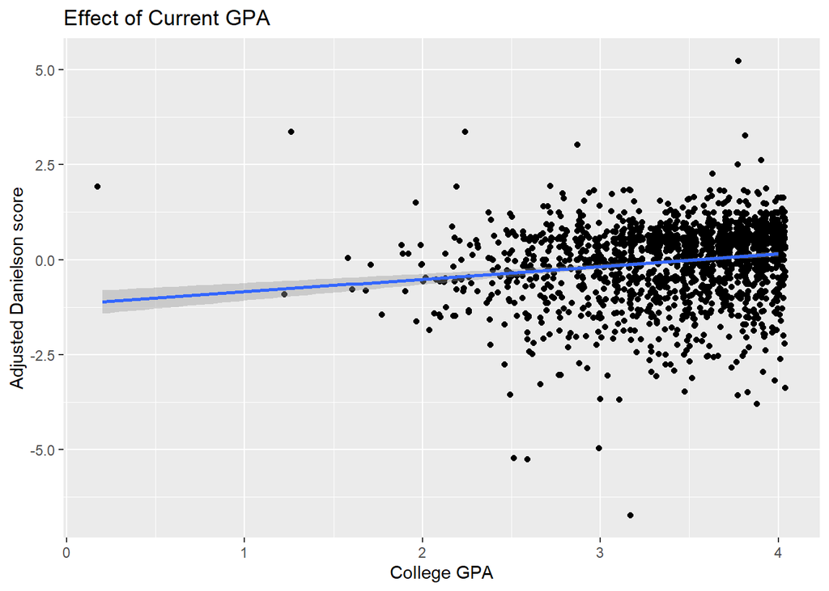

```r
ggplot(all,aes(x=CurrentCumGPA,y=WDanielson_highest_level)) +
  geom_jitter() +
  geom_smooth(method = 'lm') +
  labs(x='College GPA',y='Adjusted Danielson score',
    title="Effect of Current GPA")
```

### Danielson against HS Exam Scores

Students reported their high school exam score. The SAT and ACT score on different scales, so we’ve standardized them on a 1-36 scale.

```r
lm_dan_act <- lm(WDanielson_highest_level ~ ACTSAT_Scores, data = all)
summary(lm_dan_act) %>% pander::pander()
```

|  | Estimate | Std. Error | t value | Pr(>\|t\|) |
| --- | --- | --- | --- | --- |
| **(Intercept)** | -0.699 | 0.1474 | -4.743 | 2.311e-06 |
| **ACTSAT_Scores** | 0.03023 | 0.006437 | 4.696 | 2.896e-06 |

Fitting linear model: WDanielson_highest_level ~ ACTSAT_Scores

| Observations | Residual Std. Error | $R^2$ | Adjusted $R^2$ |
| --- | --- | --- | --- |
| 1468 | 0.9618 | 0.01482 | 0.01415 |

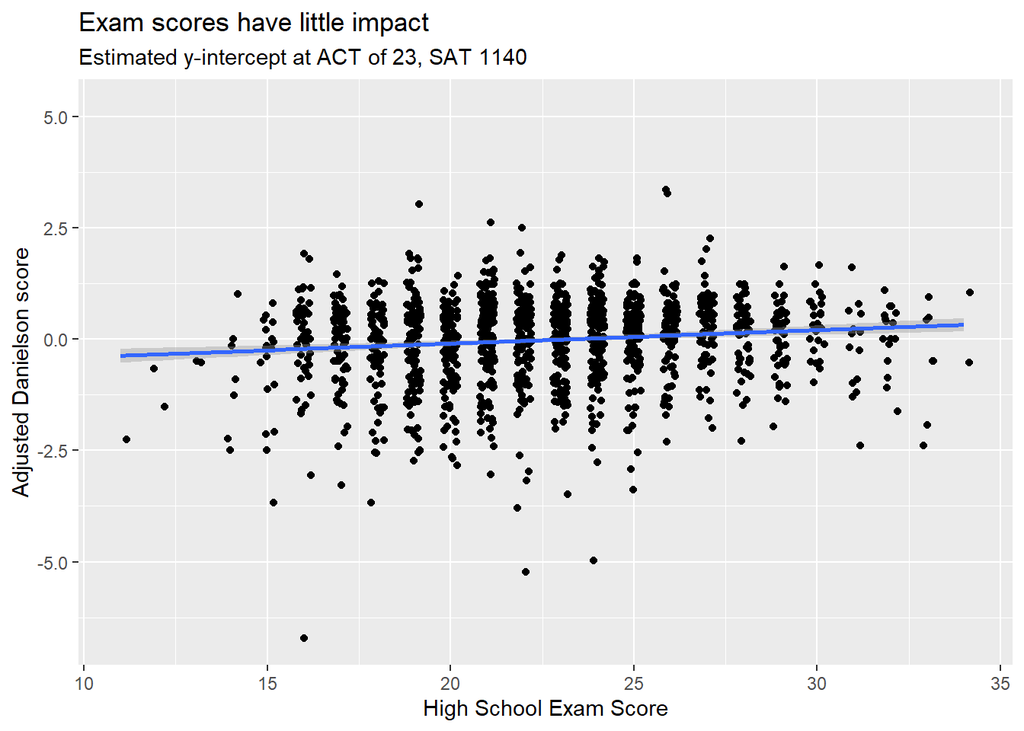

```r
ggplot(all,aes(x=ACTSAT_Scores,y=WDanielson_highest_level)) +
  geom_jitter(width = .2) +
  geom_smooth(method = 'lm') +
  labs(x='High School Exam Score',y='Adjusted Danielson score',
    title="Exam scores have little impact",
    subtitle='Estimated y-intercept at ACT of 23, SAT 1140')
```

### Danielson against Gender

```r
lm_dan_act <- lm(WDanielson_highest_level ~ isMale, data = all)
summary(lm_dan_act) %>% pander::pander()
```

|  | Estimate | Std. Error | t value | Pr(>\|t\|) |
| --- | --- | --- | --- | --- |
| **(Intercept)** | -0.001614 | 0.02567 | -0.06286 | 0.9499 |
| **isMale** | -0.195 | 0.06287 | -3.102 | 0.001951 |

Fitting linear model: WDanielson_highest_level ~ isMale

| Observations | Residual Std. Error | $R^2$ | Adjusted $R^2$ |
| --- | --- | --- | --- |
| 1776 | 0.9874 | 0.005396 | 0.004835 |

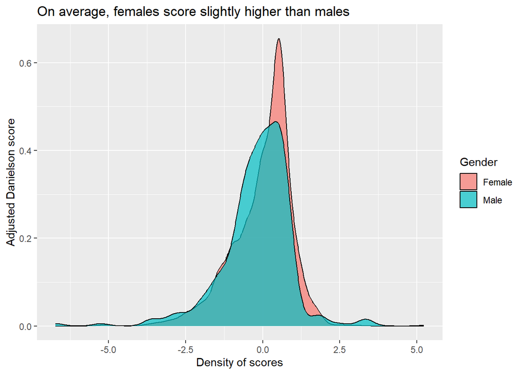

```r
all$Gender = ifelse(all$isMale==0,'Female','Male')

ggplot(all,aes(WDanielson_highest_level,group=Gender,fill=Gender)) +
  geom_density(alpha=.7) +
  labs(x='Density of scores',y='Adjusted Danielson score',
    title="On average, females score slightly higher than males")
```

### Danielson against Pell Grant reception

We again see that it doesn’t seem to matter whether or not students receive a Pell Grant during their schooling.

```r
all$Pell <- ifelse(all$ReceivedPell==0,'Did Not Receive','Received')
lm_dan_pell <- lm(WDanielson_highest_level ~ Pell,data=all)
summary(lm_dan_pell) %>% pander::pander()
```

|  | Estimate | Std. Error | t value | Pr(>\|t\|) |
| --- | --- | --- | --- | --- |
| **(Intercept)** | -0.08452 | 0.04053 | -2.085 | 0.03717 |
| **PellReceived** | 0.07586 | 0.04972 | 1.526 | 0.1273 |

Fitting linear model: WDanielson_highest_level ~ Pell

| Observations | Residual Std. Error | $R^2$ | Adjusted $R^2$ |
| --- | --- | --- | --- |
| 1776 | 0.9895 | 0.00131 | 0.0007474 |

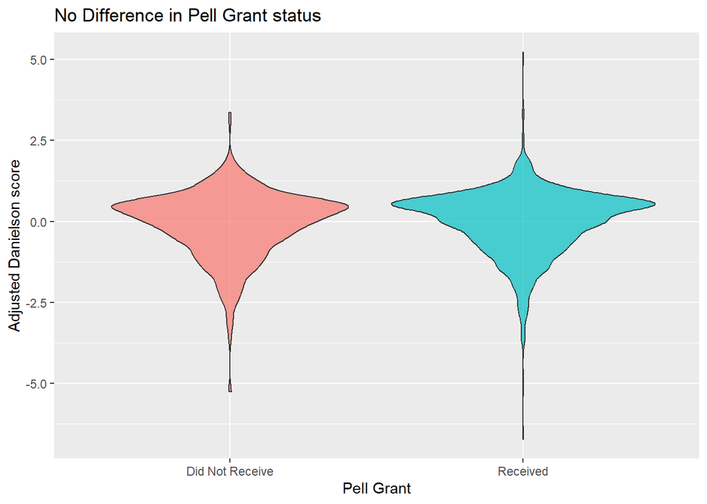

```r
ggplot(all,aes(y=WDanielson_highest_level,x=Pell,group=Pell,fill=Pell)) +
  geom_violin(alpha=.7) +
  labs(x='Pell Grant',y='Adjusted Danielson score',
    title="No Difference in Pell Grant status")  +
  theme(legend.position = 'none')
```

## Danielson against Ethnicity

To balance out the historical differences in enrollment among different ethnic groups, we’ve grouped together Hawaiians, Pacific Islanders, American Indians, and Alaskans. Here are the new counts:

```r
all$Ethnicity <- ifelse(all$Ethnicity %in% c("Hawaiian, Pacific Island","American Indian/Alaskan"),'Hawaiian, Islands, Alaskan, American Indian',all$Ethnicity)
pander(table(all$Ethnicity))
```

Table continues below

| Asian | Black | Hawaiian, Islands, Alaskan, American Indian | Hispanic, Latino | Other |
| --- | --- | --- | --- | --- |
| 32 | 10 | 8 | 120 | 13 |

| Two or More Ethnicities | Unknown | White |
| --- | --- | --- |
| 66 | 31 | 1496 |

We also find a negligible difference between the ethnic groups if we run a Kruskal-Wallis test of medians.

```r
kr_dan_ethnicity <- kruskal.test(WDanielson_highest_level ~ Ethnicity,data=all)
kr_dan_ethnicity %>% pander::pander()
```

Kruskal-Wallis rank sum test: `WDanielson_highest_level` by `Ethnicity`

| Test statistic | df | P value |
| --- | --- | --- |
| 8.652 | 7 | 0.2786 |

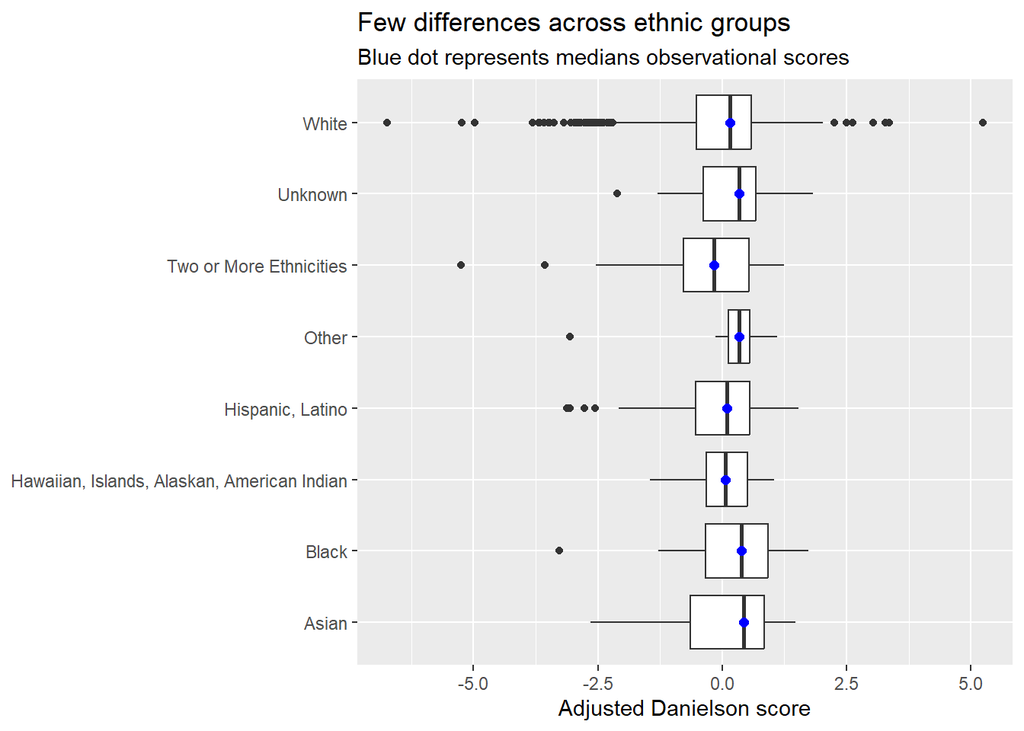

```r
ggplot(all,aes(x=Ethnicity,y=WDanielson_highest_level)) +
  geom_boxplot() +
  #geom_smooth(method = 'lm') +
  geom_point(stat = "summary",
    fun = "median",
    color='blue',size=2) +
  labs(x='Ethnicity',y='Adjusted Danielson score',
    title="Few differences across ethnic groups",
    subtitle='Blue dot represents medians observational scores') +
  coord_flip() +
  theme(axis.title.y = element_blank())
```